# STDprojet

2025-01-02

1)Installer les librairies classiques vus pendant le cours sur R

```r
#install.packages("questionr")
#install.packages("dplyr")
library (questionr)
library(dplyr)
```

2)Installer les librairies ggplot2 pour les graphiques et readxl pour importer le fichier dedonnées Excel

```r
#install.packages("readxl")
#install.packages("ggplot2")
library(readxl)
library(ggplot2)
```

3)Importer le fichier de données dans votre environnement de travail Rstudio

```r
Data_projet <- read_excel("C:/Users/lenovo/Desktop/L3 INF0/STA501/DataTest.xlsx")
```

4)Afficher les 15 premières lignes et les 15 dernières les lignes

```r
print("les 15 premières lignes:")
```

```
## [1] "les 15 premières lignes:"
```

```r
print(head(Data_projet,15))
```

```
## # A tibble: 15 × 8
##    Espèce_poisson Station_peche profondeur_peche saison année poids longueur
##    <chr>          <chr>                    <dbl> <chr>  <dbl> <dbl>    <dbl>
##  1 ABL            C                          0.5 winter     2  97.6     230.
##  2 ABL            C                          0.5 summer     2  94.4     219
##  3 ABL            C                          1.5 summer     2  97.4     228.
##  4 ABL            C                          2.5 winter     2  65.4     214
##  5 ABL            C                          3.5 summer     2  79.8     212.
##  6 ABL            C                          5.5 summer     2  93.6     230
##  7 ABL            D                          3.5 autumn     2  96.3     230
##  8 ABL            D                         12.5 winter     2  54.3     205
##  9 ABL            D                         14.5 winter     2  60.9     210
## 10 ABL            D                         15.5 winter     2  83.9     227
## 11 ABL            E                          0.5 autumn     1  86.2     212.
## 12 ABL            E                          0.5 autumn     2  88.4     215
## 13 ABL            F                          0.5 winter     2  77.4     212
## 14 ABL            F                          5.5 autumn     1 104.      223
## 15 ABL            F                          6.5 winter     2  70.2     205
## # ℹ 1 more variable: Nombre_Captures <dbl>
```

```r
print("les 15 dernières les lignes:")
```

```
## [1] "les 15 dernières les lignes:"
```

```r
print(tail(Data_projet,15))
```

```
## # A tibble: 15 × 8
##    Espèce_poisson Station_peche profondeur_peche saison année poids longueur
##    <chr>          <chr>                    <dbl> <chr>  <dbl> <dbl>    <dbl>
##  1 TAN            B                          1.5 summer     2 1536.     445
##  2 TAN            C                          1.5 summer     2  805.     379
##  3 TAN            C                          6.5 summer     2  805.     379
##  4 TAN            C                          7.5 winter     2 1235.     430
##  5 TAN            D                          0.5 summer     2 1229.     436
##  6 TAN            D                          1.5 summer     2 1111      400
##  7 TAN            D                         19.5 autumn     1 1131.     435
##  8 TAN            E                          3.5 summer     2 1186.     435.
##  9 TAN            E                          4.5 summer     2 1197      440
## 10 TAN            G                          1.5 summer     2 1106      425
## 11 TAN            G                          1.5 summer     2 1079.     365
## 12 TAN            G                          3.5 autumn     2 1273      422
## 13 TAN            G                          3.5 summer     2 1096      416
## 14 TAN            G                          4.5 summer     2 1111      420
## 15 TAN            H                          8.5 summer     2  402.     296
## # ℹ 1 more variable: Nombre_Captures <dbl>
```

5)Afficher le résumé des données

```r
summary(Data_projet)
```

```
##  Espèce_poisson     Station_peche      profondeur_peche    saison
##  Length:1205        Length:1205        Min.   : 0.500   Length:1205
##  Class :character   Class :character   1st Qu.: 2.500   Class :character
##  Mode  :character   Mode  :character   Median : 4.500   Mode  :character
##                                        Mean   : 5.995
##                                        3rd Qu.: 8.500
##                                        Max.   :19.500
##      année           poids            longueur     Nombre_Captures
##  Min.   :1.000   Min.   :   1.44   Min.   : 60.0   Min.   : 1.000
##  1st Qu.:2.000   1st Qu.:  93.50   1st Qu.:200.0   1st Qu.: 1.000
##  Median :2.000   Median : 339.20   Median :300.0   Median : 1.000
##  Mean   :1.758   Mean   : 417.89   Mean   :285.6   Mean   : 1.793
##  3rd Qu.:2.000   3rd Qu.: 522.00   3rd Qu.:340.0   3rd Qu.: 2.000
##  Max.   :2.000   Max.   :7850.00   Max.   :927.0   Max.   :38.000
```

6)En utilisant la première colonne (Data_projet$Espèce_poisson), représenter sous forme de diagramme en bâton les espèces de poissons (en abscisse) en fonction de leur fréquence (en ordonnée)

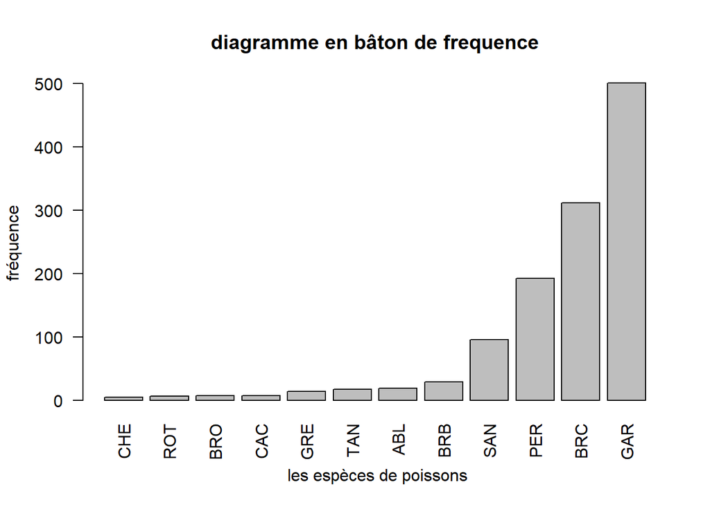

```r
poisson_freq_espece=sort(table(Data_projet$Espèce_poisson))
barplot(poisson_freq_espece, main = "diagramme en bâton de frequence",
        xlab = " les espèces de poissons",
        ylab = "fréquence", las = 2)
```

Remarque : L’axe horizontal représente les espèces de poissons, et l’axe vertical indique la fréquence d’apparition de chaque espèce. Conclusion : On peut voir que le GAR a été capturé le plus souvent, suivi par le BRC et le PER etc,le plus petit(moindre) est CHE.

7)En utilisant la colonne (Data_projet$poids), représenter sous forme de diagramme en bâton le poids des poissons en fonction de leur fréquence

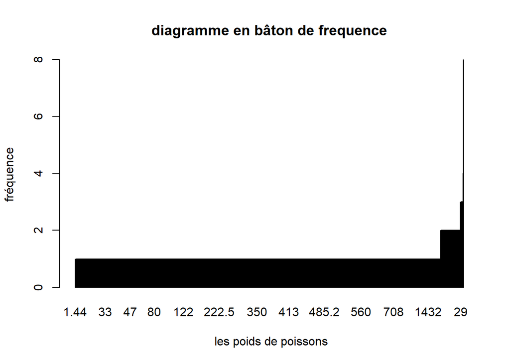

```r
poisson_freq_poids=sort(table(Data_projet$poids))
barplot(poisson_freq_poids, main = "diagramme en bâton de frequence",
        xlab = " les poids de poissons", ylab = "fréquence")
```

8. En utilisant la colonne (Data_projet$longueur), représenter sous forme de diagramme en bâton la longueur des poissons en fonction de leur fréquence

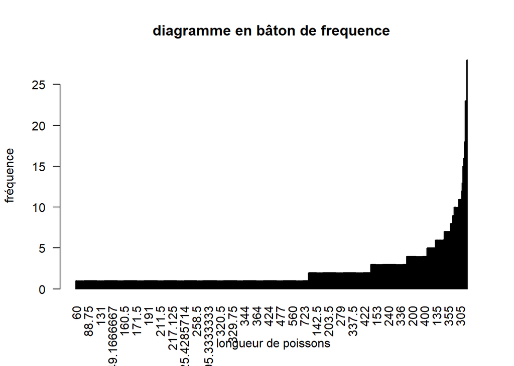

```r
poisson_freq_longueur=sort(table(Data_projet$longueur))
barplot(poisson_freq_longueur,main = "diagramme en bâton de frequence",xlab = " longueur de poissons",
           ylab = "fréquence",las = 2)
```

9)Sur un même graphique, représenter sous forme de boite à moustache (boxplot), la distribution des poids de chaque espèce de poisson. Les boites à moustaches auront des couleurs différentes et seront associées à chacune des espèces.

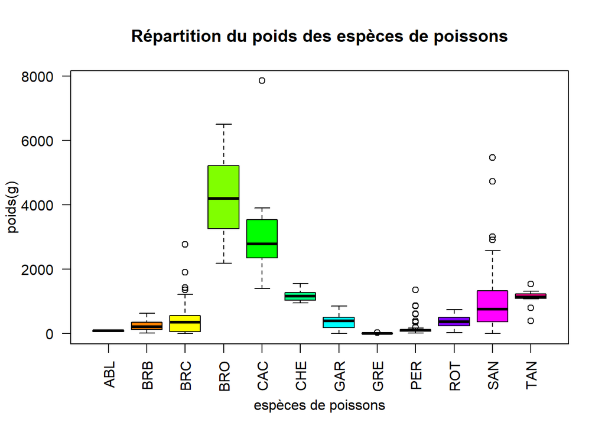

```r
boxplot(Data_projet$poids ~ Data_projet$Espèce_poisson,main = "Répartition du poids des espèces de poissons",
        xlab = "espèces de poissons",
        ylab = "poids(g)",
        col = rainbow(length(unique(Data_projet$Espèce_poisson))),
        las = 2)
```

10)Sur un même graphique, représenter sous forme de boite à moustache (boxplot),la distribution des longueurs de chaque espèce de poisson. Les boites à moustaches auront des couleurs différentes et seront associées à chacune des espèces.

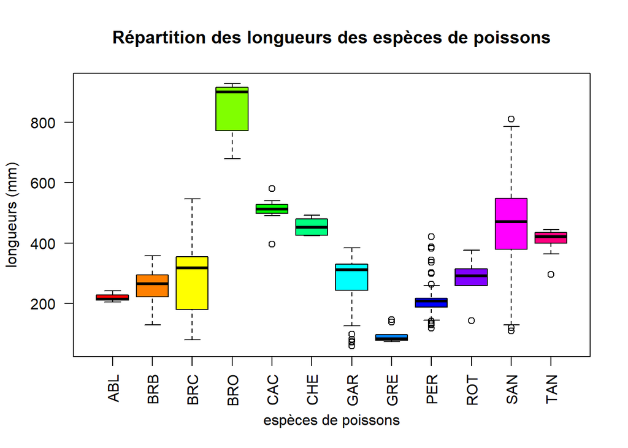

```r
boxplot(Data_projet$longueur ~ Data_projet$Espèce_poisson,
        main = "Répartition des longueurs des espèces de poissons",
        xlab = "espèces de poissons",
        ylab = "longueurs (mm)",
        col =rainbow(length(unique(Data_projet$Espèce_poisson))),
        las = 2)
```

11. Représenter sous forme de nuage de points le poids des poissons fonction de leur longueur

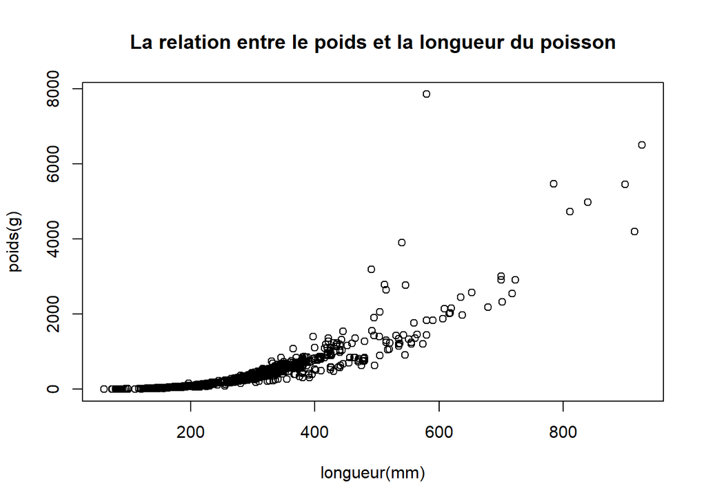

```r
plot(Data_projet$longueur, Data_projet$poids,
     main = "La relation entre le poids et la longueur du poisson",
     xlab = "longueur(mm)",
     ylab = "poids(g)")
```

Remarque : L’axe horizontal représente la longueur, l’axe vertical représente le poids, chaque point montre deux indicateurs d’un poisson. Conclusion : Le poids et la longueur sont positivement corrélés, les poissons plus longs sont généralement plus lourds.

12)Faire une régression de linéaire de poids en fonction de la longueur des poissons

```r
model=lm(poids ~ longueur, data = Data_projet)
summary(model)
```

```
##
## Call:
## lm(formula = poids ~ longueur, data = Data_projet)
##
## Residuals:
##    Min     1Q Median     3Q    Max
## -676.2 -134.4  -61.8   82.2 6194.6
##
## Coefficients:
##               Estimate Std. Error t value Pr(>|t|)
## (Intercept) -782.25863   25.35897  -30.85   <2e-16 ***
## longueur       4.20288    0.08223   51.11   <2e-16 ***
## ---
## Signif. codes:  0 '***' 0.001 '**' 0.01 '*' 0.05 '.' 0.1 ' ' 1
##
## Residual standard error: 332.5 on 1203 degrees of freedom
## Multiple R-squared:  0.6847, Adjusted R-squared:  0.6844
## F-statistic:  2612 on 1 and 1203 DF,  p-value: < 2.2e-16
```

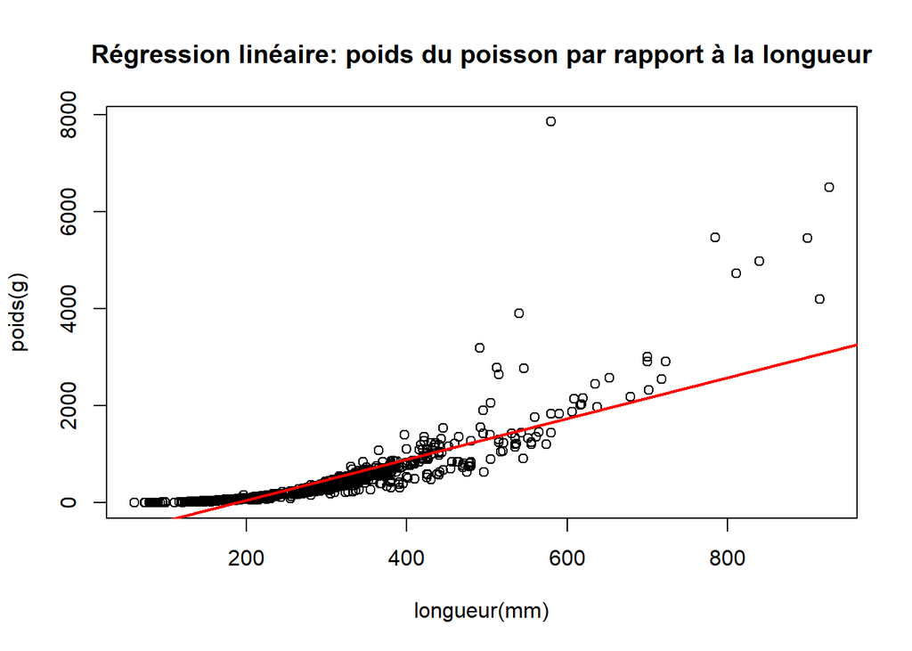

```r
plot(Data_projet$longueur, Data_projet$poids,
main = "Régression linéaire: poids du poisson par rapport à la longueur",
     xlab = "longueur(mm)",
     ylab = "poids(g)")

#ligne
abline(model, col = "red", lwd = 2)
```

Remarque : L’équation de régression est de la forme : poids = a + b * longueur Selon les données de sortie de summary (Coefficients): On a poids = -782.26 + 4.2 * longueur D’après le nuage de points de la question précédente. On a trouvé qu’il y a une relation linéaire positive significative entre le poids et la longueur des poissons.Plus la longueur est grande, plus le poids est lourd.

13)Faire un Khi-2 non testé pour savoir et une différence de signification entre les stations Quand au sujet du nombre d’espèces de poissons dans chaque station.

```r
tab=table(Data_projet$Station_peche,Data_projet$Espèce_poisson)
# test-chi2
chi2_test <- chisq.test(tab)
# res de chi2
print(chi2_test)
```

```
##
##  Pearson's Chi-squared test
##
## data:  tab
## X-squared = 234.53, df = 77, p-value < 2.2e-16
```

```r
cat("statistique du chi2:",chi2_test$statistic,"\n")
```

```
## statistique du chi2: 234.5345
```

```r
cat("ddl:",chi2_test$parameter,"\n")
```

```
## ddl: 77
```

```r
cat("P:",chi2_test$p.value, "\n")
```

```
## P: 8.003721e-18
```

```r
if (chi2_test$p.value < 0.05) {
  print("Conclusion: Il existe des différences significatives dans la répartition des espèces de poissons selon les sites.\n")
} else {
  print("Conclusion:Il n'y a pas de différence significative dans la répartition des espèces de poissons selon les sites.\n")
}
```

```
## [1] "Conclusion: Il existe des différences significatives dans la répartition des espèces de poissons selon les sites.\n"
```

Remarque : Vérifier s’il y a un lien entre les sites d’échantillonnage et la distribution des espèces de poissons. La valeur du chi carré et la valeur P montrent si c’est significatif. Conclusion : On a un P < 0,05, donc la distribution des poissons dépend vraiment des sites, ce qui montre qu’il y a des différences claires dans les espèces de poissons capturées selon les sites.

14. Faire un mini rapport contenant vos résultats graphiques et statistiques que vous interpréterez. Mettez aussi votre code R dans le mini rapport. Résumé : Ces analyses montrent qu’il y a une relation significative entre le poids et la longueur des poissons. La distribution des différentes espèces de poissons est influencée par plusieurs facteurs comme le site et les caractéristiques de chaque espèce.